# Tombola analysis

# Tombola

# Mathematical analysis

The objective is to understand at each point of the game what is the probability that a card makes tombola, and also for the minor prizes (ambo, terna, etc.)

The probability that a card has a drawn number depends on two factors: the number of free numbers on the card and the number of numbers in the drum.

The probability that a card has an “hit” (the number drawn is on the card is):

$$P(H_{t, k}) = \frac{c-k}{d - t}$$
where:

- $t$ is the time step (how many numbers have been drawn)
- $k$ is the class of the card (how many hits it had to far)
- $P(H)$ is the probability of an hit
- $d$ is the number of numbers in the drum
- $c$ is the number of numbers in the card

From this formula is possible to calculate the fraction of cards in a class $k$ at time $t$.

This is the sum of two components:

- the fraction of card in the previous class ($k-1$) present at time $t-1$, that a time $t$ have an hit. Hence they increase the class at time $t$.
- the fraction of the cards in the class $k$ at time $t-1$, that at time $t$ **don’t** have an hit.

or in math:

$$N_{t,k} = N_{t-1, k-1}P(H_{t, k-1}) + N_{t-1, k}(1 - P(H_{t, k}))$$

This equations are all what is needed to model the tombola game, so now it can be implemented in code

## Implement in code

### Step 1

Naive implementation of the functions in code

```r
p_H <- function(t,k){
  (n_c - k) / (n_d - t)
}
```

```r
N <- function(t, k){
  N(t-1, k-1) * p_H(t, k-1) + N(t-1, k) * (1 - p_H(t,k) )
}
```

### Step 2

The function `N` calls recursively itself, which works but it will never stop, so the solution is to have an initial state hardcoded into the function for `t=0`

```r
N <- function(t, k){
  if(t == 0){
    ifelse(k == 0, 1, 0) # 1 means all the card are in class 0
  }
  else{
    N(t-1, k-1) * p_H(t-1, k-1) + N(t-1, k) * (1 - p_H(t-1,k))
  }
}
```

### Step 3

The function `N` now it works but is very slow, because it needs to call itself a number of times that increase exponentially with `t`, so we use *memoization* to cache the results.

In R it can be simply done as

```r
N <- memoise(N)
```

### Step 4

Finally we want the system to be flexible and allow for different values of `n_c` and `n_d`

```r
# this functions returns the N function for a particular game
get_game_N <- function(n_c, n_d){

  p_H <- function(t,k){
        (n_c - k) / (n_d - t)
  }

  N <- function(t, k){
      if(t == 0){
        ifelse(k == 0, 1, 0) # 1 means all the card are in class 0
      }
      else{
        N(t-1, k-1) * p_H(t-1, k-1) + N(t-1, k) * (1 - p_H(t-1,k))
      }
    }
  N <- memoise(N)
  return(N)
}
```

# Result

## Tombola

with all the code is possible to calculate the probabilities for each class at all time steps

```r
all_game_status <- function(n_c, n_d){
  N <- get_game_N(n_c, n_d)
  game_status <- matrix(nrow = n_d, ncol=n_c+1)

  for (t in 1:n_d){
    for (k in 0:n_c){
      game_status[t, k+1] <- N(t, k) # The k+1 is needed because R indexes starts from 1 and not 0 like the classes
    }
  }

  game_status <- game_status %>%
    as.data.frame() %>%
    as_tibble() %>%
    mutate(time = 1:n_d) %>%
    relocate(time)

  names(game_status) <- c("time", 0:n_c)

  game_status

}
```

```r
tombola <- all_game_status(15, 90) # number fo tombola
tombola
```

```
## # A tibble: 90 × 17
##     time   `0`   `1`    `2`     `3`      `4`       `5`      `6`      `7`     `8`
##    <int> <dbl> <dbl>  <dbl>   <dbl>    <dbl>     <dbl>    <dbl>    <dbl>   <dbl>
##  1     1 0.833 0.167 0      0       0        0          0        0       0
##  2     2 0.693 0.281 0.0262 0       0        0          0        0       0
##  3     3 0.575 0.354 0.0670 0.00387 0        0          0        0       0
##  4     4 0.476 0.396 0.114  0.0134  0.000534 0          0        0       0
##  5     5 0.393 0.415 0.161  0.0287  0.00233  0.0000683  0        0       0
##  6     6 0.323 0.416 0.205  0.0493  0.00608  0.000362   8.04e-6  0       0
##  7     7 0.266 0.404 0.243  0.0740  0.0123   0.00112    5.02e-5  8.61e-7 0
##  8     8 0.218 0.384 0.273  0.101   0.0214   0.00262    1.79e-4  6.23e-6 8.30e-8
##  9     9 0.178 0.358 0.295  0.130   0.0334   0.00517    4.79e-4  2.53e-5 6.83e-7
## 10    10 0.145 0.329 0.310  0.158   0.0480   0.00906    1.06e-3  7.60e-5 3.12e-6
## # … with 80 more rows, and 7 more variables: 9 <dbl>, 10 <dbl>, 11 <dbl>,
## #   12 <dbl>, 13 <dbl>, 14 <dbl>, 15 <dbl>
```

```r
# tidy dataframe for easier plotting
tombola_td <- tombola %>%
  pivot_longer(-time, names_to = "numbers", values_to = "fraction") %>%
  mutate(numbers = factor(numbers, levels = numbers %>%  as.integer() %>% unique()))
```

here there are the results for tombola

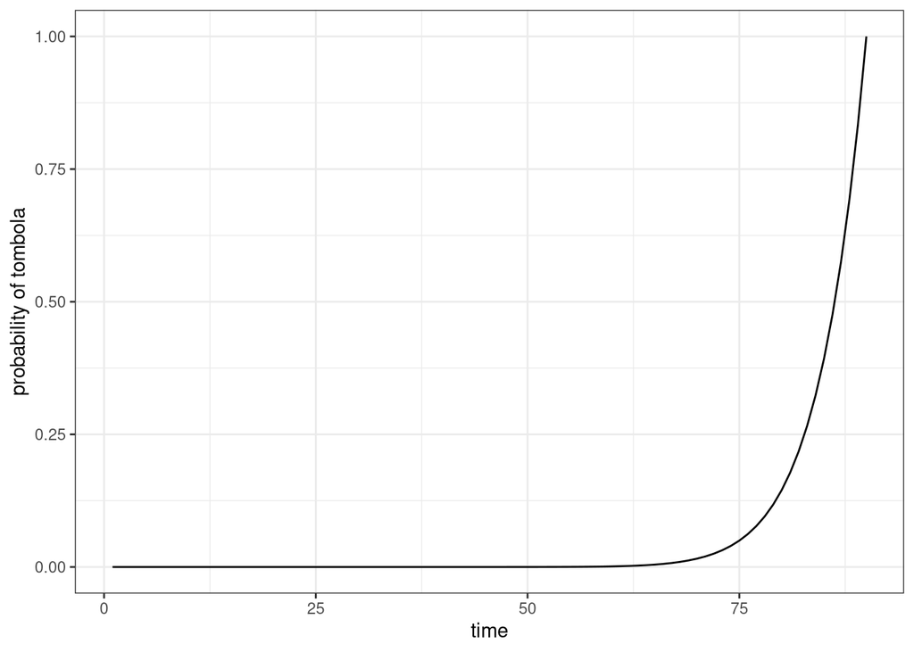

```r
tombola %>%
  ggplot() +
  geom_line(aes(time, `15`)) +
  labs(y="probability of tombola")
```

for all classes

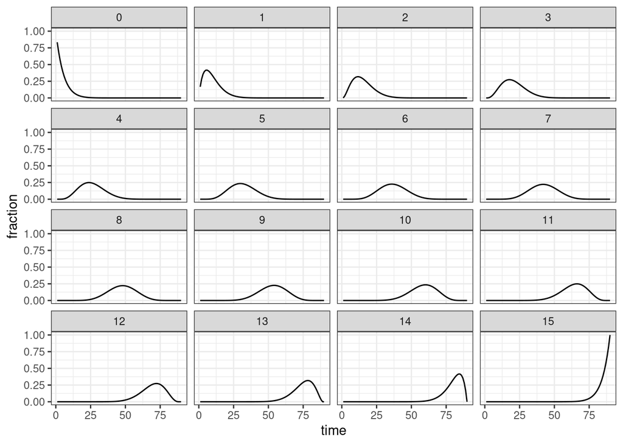

```r
tombola_td %>%
  ggplot() +
  geom_line(aes(time, fraction)) +
  facet_wrap(~numbers)
```

Probability of having done at least `k` hits at each time

```r
totalprob <- function(x){
  end <- length(x)
  map_dbl(seq_along(x),~sum(x[.x:end]))
}
```

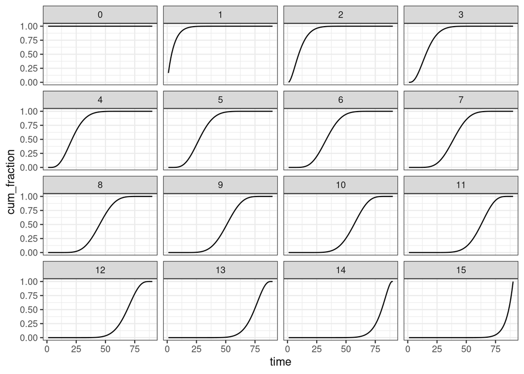

```r
tombola_td %>%
  group_by(time) %>%
  summarize(cum_fraction = totalprob(fraction), numbers, .groups="keep") %>%
  ggplot() +
  geom_line(aes(time, cum_fraction)) +
  facet_wrap(~numbers)
```

## Minor prizes

the approach is the same for tombola, but instead of having have a card with 15 numbers we use consider the length of the row as a card, in this case 5.

```r
tombola_minor <- all_game_status(5, 90)
```

```r
tombola_minor_td <- tombola_minor %>%
  pivot_longer(-time, names_to = "numbers", values_to = "fraction") %>%
  mutate(numbers = factor(numbers, levels = numbers %>%  as.integer() %>% unique()))
```

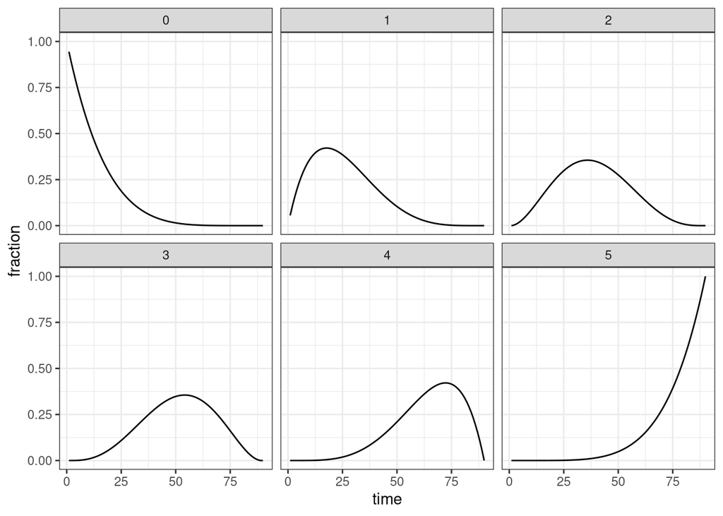

```r
tombola_minor_td %>%
  ggplot() +
  geom_line(aes(time, fraction)) +
  facet_wrap(~numbers)
```

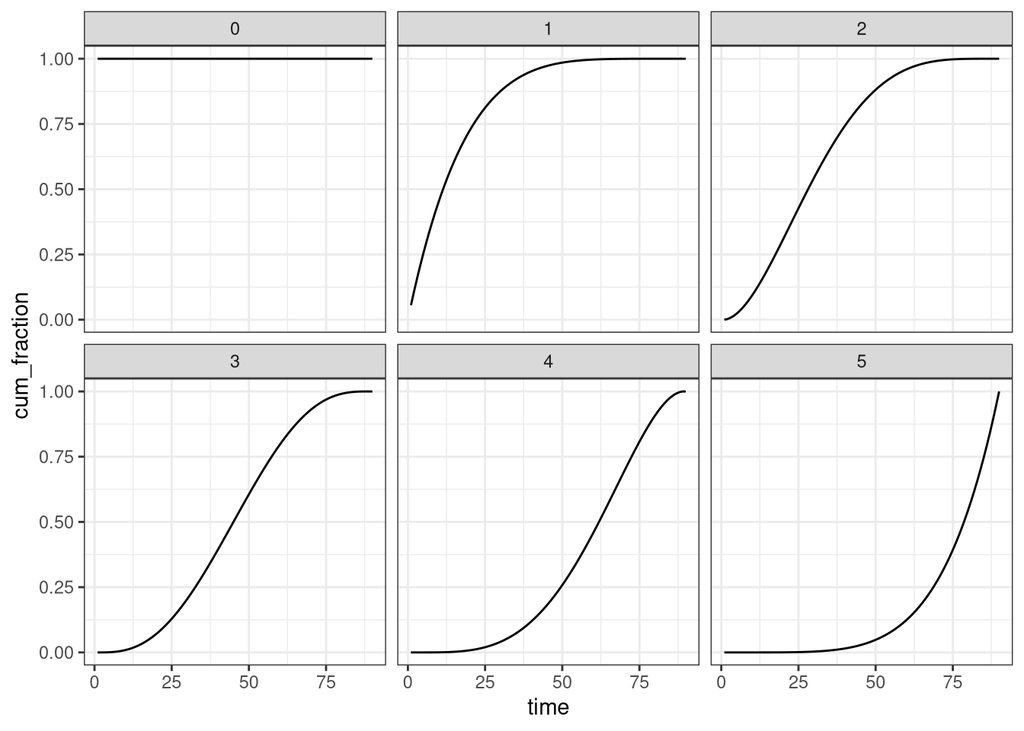

```r
tombola_minor_td %>%
  group_by(time) %>%
  summarize(cum_fraction = totalprob(fraction), numbers, .groups="keep") %>%
  ggplot() +
  geom_line(aes(time, cum_fraction)) +
  facet_wrap(~numbers)
```

# Extra

Calculating the total number of possible games and possible card in tombola.

```r
combination <- function(n,k){
  factorial(n) / (factorial(k) * factorial(n - k))
}
permutation <- function(n,k){
  factorial(n) / factorial(n-k)
}
```

total number of possible “games”

```r
permutation(90, 90)
```

```
## [1] 1.485716e+138
```

number of possible cards

```r
combination(90, 15)
```

```
## [1] 4.579567e+16
```